# Short PCA Vignette

Aedin

May 1, 2018

# 1 Toy data

Create a cloud of points; two vectors, x,y of length 100. This example dataset was included in Lior Patcher’s blog https://liorpachter.wordpress.com/tag/least-squares/

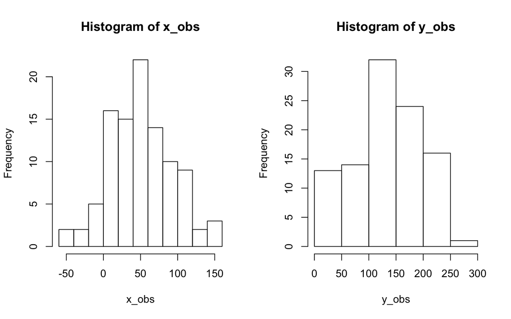

```r
 set.seed(2)             #sets the seed for random number generation.
 x <- 1:100              #creates a vector x with numbers from 1 to 100
 ex <- rnorm(100, 0, 30) #100 normally distributed random numbers, mean=0, sd=30
 ey <- rnorm(100, 0, 30) # 100 normally distributed random numbers, mean=0, sd=30
 y <- 30 + 2 * x         #sets y to be a vector that is a linear function of x
 x_obs <- x + ex         #adds "noise" to x
 y_obs <- y + ey         #adds "noise" to y
 par(mfrow=c(1,2))
 hist(x_obs)
 hist(y_obs)
```

Save both vectors in a matrix P

```r
P <- cbind(x_obs,y_obs) #places points in matrix
summary(P)
```

```
##      x_obs            y_obs
##  Min.   :-53.33   Min.   : 14.13
##  1st Qu.: 21.44   1st Qu.: 97.22
##  Median : 44.37   Median :134.91
##  Mean   : 49.58   Mean   :131.88
##  3rd Qu.: 77.91   3rd Qu.:174.29
##  Max.   :155.78   Max.   :252.63
```

Plot x,y. Show center (mean (x), mean(y)) on plot

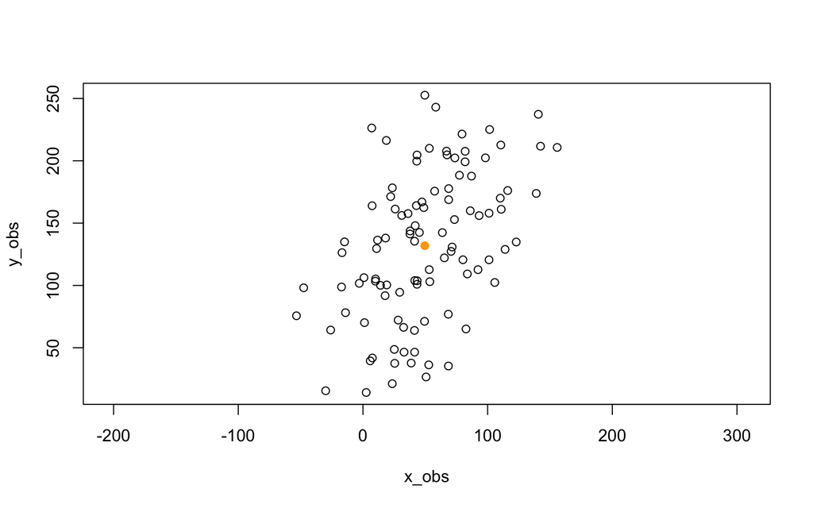

```r
plot(P,asp=1,col=1) #plot points
points(x=mean(x_obs),y=mean(y_obs),col="orange", pch=19) #show center
```

# 2 Computing via svd of centered, covariance matrix

PCA can be computed as a singular value decomposition of a column centered matrix. Therefore we first processs the matrix.

```r
M <- cbind(x_obs-mean(x_obs),y_obs-mean(y_obs))#centered matrix
Mx<-scale(P, scale=FALSE, center=TRUE)
all.equal(M, Mx, check.attributes=FALSE)  # Is M equal to Mx, ignore col names
```

```
## [1] TRUE
```

Singular value decomposition of M. The singular value decomposition of M decomposes it into M=UDV<sup>t</sup> where D is a diagonal matrix and both U and V<sup>t</sup> are orthogonal matrices.

```r
 d <- svd(M)$d          #the singular values
 v <- svd(M)$v          #the right singular vectors
svd(M)$v
```

```
##           [,1]       [,2]
## [1,] 0.4527354 -0.8916449
## [2,] 0.8916449  0.4527354
```

# 3 Eigenvector, Eigenvalues of the centered, covariance matrix

The eigenvectors of the covariance matrix provide the principal axes, and the eigenvalues quantify the fraction of variance explained in each component.

```r
MCov <- cov(M)          #creates covariance matrix
eigenValues <- eigen(MCov)$values       #compute eigenvalues
eigenVectors <- eigen(MCov)$vectors     #compute eigenvectors
eigenValues
```

```
## [1] 4110.45 1189.45
```

```r
eigenVectors
```

```
##           [,1]       [,2]
## [1,] 0.4527354 -0.8916449
## [2,] 0.8916449  0.4527354
```

The right singular vectors are the eigenvectors of M<sup>t</sup>M. Next I plot the principal axes:

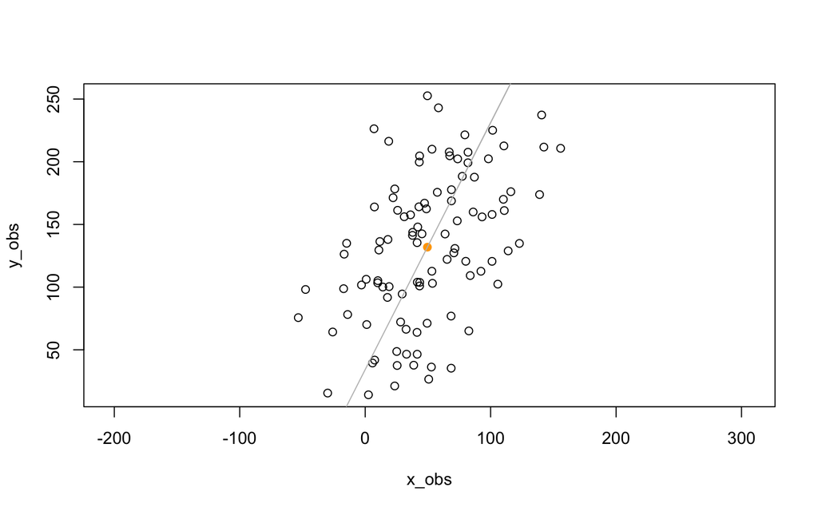

```r
plot(P,asp=1,col=1) #plot points
points(x=mean(x_obs),y=mean(y_obs),col="orange", pch=19) #show center
lines(x_obs,eigenVectors[2,1]/eigenVectors[1,1]*M[x]+mean(y_obs),col=8)
```

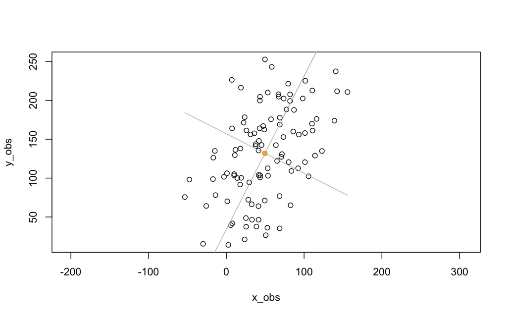

```r
plot(P,asp=1,col=1) #plot points
points(x=mean(x_obs),y=mean(y_obs),col="orange", pch=19) #show center
lines(x_obs,eigenVectors[2,1]/eigenVectors[1,1]*M[x]+mean(y_obs),col=8)
lines(x_obs,eigenVectors[2,2]/eigenVectors[1,2]*M[x]+mean(y_obs),col=8)
```

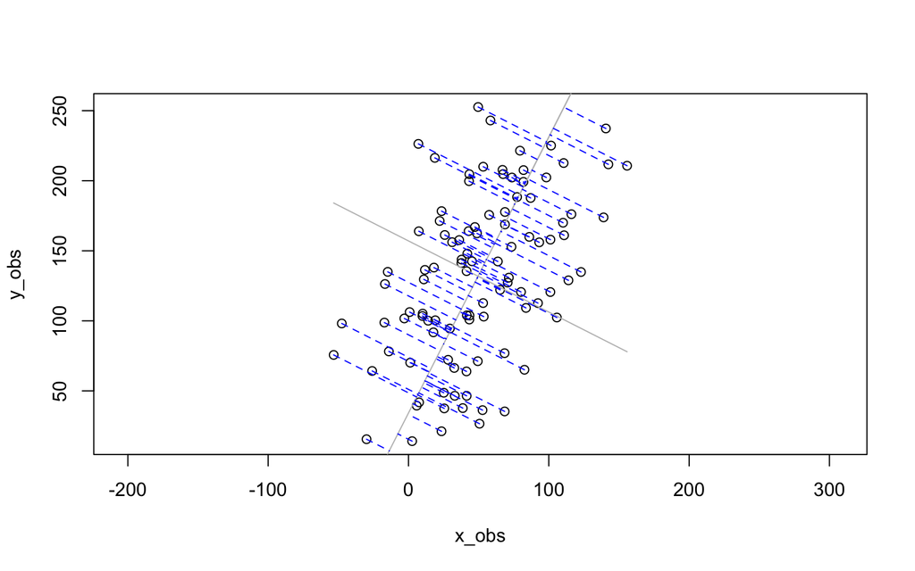

```r
trans <- (M%*%v[,1])%*%v[,1] #compute projections of points
P_proj <- scale(trans, center=-cbind(mean(x_obs),mean(y_obs)), scale=FALSE)

plot(P,asp=1,col=1) #plot points
lines(x_obs,eigenVectors[2,1]/eigenVectors[1,1]*M[x]+mean(y_obs),col=8)
lines(x_obs,eigenVectors[2,2]/eigenVectors[1,2]*M[x]+mean(y_obs),col=8)
#points(P_proj, col=4,pch=19,cex=0.5) #plot projections
segments(x_obs,y_obs,P_proj[,1],P_proj[,2],col=4,lty=2) #connect to points
```

# 4 PCA in R

In R, there are several functions from different packages that allow us to perform PCA. These include;

- prcomp() (stats)
- princomp() (stats)
- PCA() (FactoMineR)
- dudi.pca() (ade4)

We will demonstrate some of these and explore these using exploR

# 5 Equivalents across methods

Give an input matrix P and result res

| Function | loadings | scores | plot |
| --- | --- | --- | --- |
| prcomp(P, center=TRUE, scale=TRUE) | res$rotation | res$x | biplot(res) |
| princomp(P, cor=TRUE) | res$loadings | res$scores | biplot(res) |
| PCA(P) | res$svd$V | res$ind$coord | plot(res) |
| dudi.pca(P, center=TRUE, scale=TRUE) | res$c1 | res$li | scatter(res) |

## 5.1 svd

To get the equivalent result using svd or eigen above, repeat the code above but scale and center the data scale(P, center=TRUE, scale=TRUE).

```r
svd(scale(P))$v
```

```
##           [,1]       [,2]
## [1,] 0.7071068 -0.7071068
## [2,] 0.7071068  0.7071068
```

## 5.2 prcomp

First stats::prcomp. The eigenvector are stored in $rotation

```r
p1<- prcomp(P, scale = TRUE)
p1
```

```
## Standard deviations (1, .., p=2):
## [1] 1.212661 0.727635
##
## Rotation (n x k) = (2 x 2):
##             PC1        PC2
## x_obs 0.7071068 -0.7071068
## y_obs 0.7071068  0.7071068
```

```r
summary(p1)
```

```
## Importance of components:
##                           PC1    PC2
## Standard deviation     1.2127 0.7276
## Proportion of Variance 0.7353 0.2647
## Cumulative Proportion  0.7353 1.0000
```

```r
# This can be calculated as;
eigs= p1$sdev^2
eigSum= rbind(
  SD = sqrt(eigs),
  Proportion = eigs/sum(eigs),
  Cumulative = cumsum(eigs)/sum(eigs))

eigSum
```

```
##                 [,1]      [,2]
## SD         1.2126612 0.7276350
## Proportion 0.7352736 0.2647264
## Cumulative 0.7352736 1.0000000
```

# 6 princomp

```r
p2<-stats::princomp(P)

# sqrt of eigenvalues
p2$sdev
```

```
##   Comp.1   Comp.2
## 63.79142 34.31553
```

```r
# eigenvectors
p2$loadings
```

```
##
## Loadings:
##       Comp.1 Comp.2
## x_obs  0.453  0.892
## y_obs  0.892 -0.453
##
##                Comp.1 Comp.2
## SS loadings       1.0    1.0
## Proportion Var    0.5    0.5
## Cumulative Var    0.5    1.0
```

## 6.1 FactoMineR

FactoMineR::PCA calls svd to compute the PCA

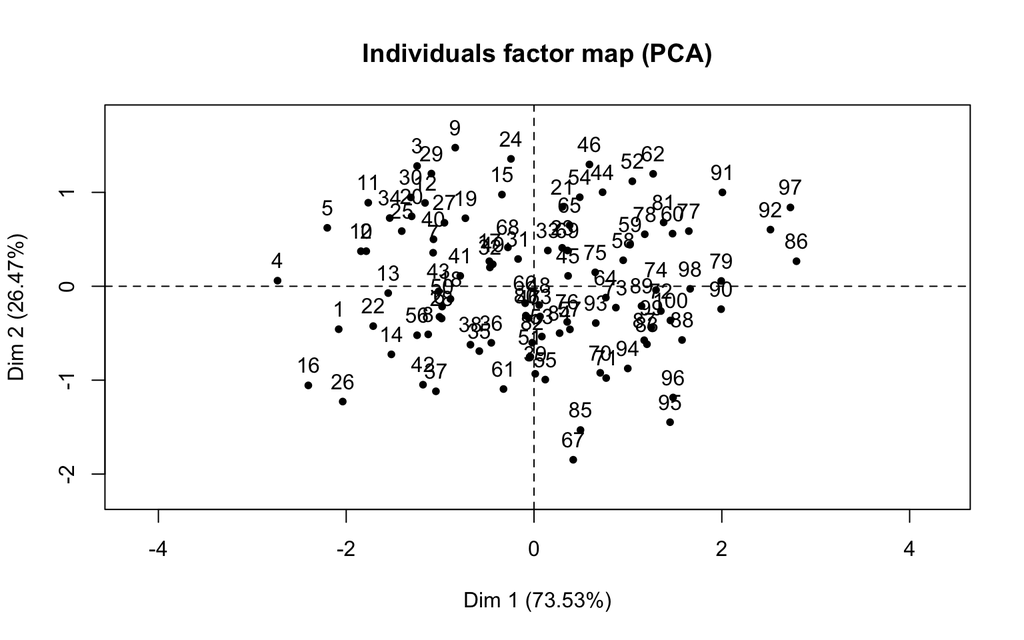

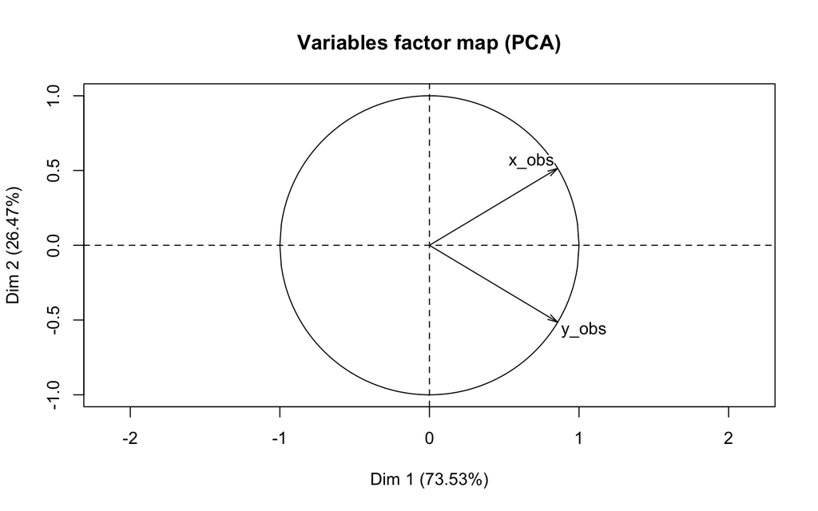

```r
p3<-FactoMineR::PCA(P)
```

```r
p3$eig
```

```
##        eigenvalue percentage of variance cumulative percentage of variance
## comp 1  1.4705472               73.52736                          73.52736
## comp 2  0.5294528               26.47264                         100.00000
```

```r
p3$var$coord  # correlations between variables and PCs
```

```
##          Dim.1      Dim.2
## x_obs 0.857481  0.5145157
## y_obs 0.857481 -0.5145157
```

## 6.2 ADE4::dudi.pca

First ade4::dudi.pca scales the data and stores the scaled data in $tab. In PCA this will be almost equivalent to scale. However there is a minor difference (see https://pbil.univ-lyon1.fr/R/pdf/course2.pdf). ade4 usees the duality diagram framework for computing pca and other matrix factorizations (so it provides lw and cw which are the row and columns weights). See Cruz and Holmes 2011 for a wonderful tutorial on the duality diagram framework https://www.ncbi.nlm.nih.gov/pmc/articles/PMC3265363/

```r
p4<-ade4::dudi.pca(P, scannf = FALSE, nf=2)  # save 2 axis by default,
head(p4$tab)  # centered/scaled data.
```

```
##         x_obs      y_obs
## 1 -1.79410466 -1.1472082
## 2 -0.99902168 -1.5273772
## 3  0.02510543 -1.7859484
## 4 -1.88926469 -1.9735368
## 5 -1.11674143 -1.9968913
## 6 -0.94133545 -0.4822568
```

```r
head(scale(P))
```

```
##            x_obs      y_obs
## [1,] -1.78511160 -1.1414577
## [2,] -0.99401402 -1.5197211
## [3,]  0.02497959 -1.7769963
## [4,] -1.87979464 -1.9636443
## [5,] -1.11114369 -1.9868817
## [6,] -0.93661695 -0.4798394
```

The values used for centering are stored in cent, it is a the colMeans. norm provides the sd of the columns

```r
p4$cent == colMeans(P)
```

```
## x_obs y_obs
##  TRUE  TRUE
```

```r
sd.n <- function(x) sqrt(var(x) * (length(x) - 1)/length(x))
identical(p4$norm,apply(P, 2, sd.n))
```

```
## [1] TRUE
```

The summary printout is equivalent to P3 (p3$eig) above. The eigenvales are stored in p4$eig.

```r
summary(p4)
```

```
## Class: pca dudi
## Call: ade4::dudi.pca(df = P, scannf = FALSE, nf = 2)
##
## Total inertia: 2
##
## Eigenvalues:
##     Ax1     Ax2
##  1.4705  0.5295
##
## Projected inertia (%):
##     Ax1     Ax2
##   73.53   26.47
##
## Cumulative projected inertia (%):
##     Ax1   Ax1:2
##   73.53  100.00
```

```r
p4$eig
```

```
## [1] 1.4705472 0.5294528
```

```r
p4$c1
```

```
##             CS1        CS2
## x_obs 0.7071068 -0.7071068
## y_obs 0.7071068  0.7071068
```

```r
p4$co
```

```
##          Comp1      Comp2
## x_obs 0.857481 -0.5145157
## y_obs 0.857481  0.5145157
```

The cumulative % of variance explained by each component ;

```r
(k <- 100 * p4$eig/sum(p4$eig))
```

```
## [1] 73.52736 26.47264
```

```r
cumsum(k)
```

```
## [1]  73.52736 100.00000
```

```r
p4$nf
```

```
## [1] 2
```

c1 gives the variables’ coordinates, normed to 1. It is also called the coefficients of the combination or the loadings of variables. Equally the outpur matrix l1 gives the individuals’ coordinates, normed to 1. It is also called the loadings of individuals.

```r
p4$c1
```

```
##             CS1        CS2
## x_obs 0.7071068 -0.7071068
## y_obs 0.7071068  0.7071068
```

```r
sum(p4$cw * p4$c1$CS1^2)
```

```
## [1] 1
```

co gives the variables’ coordinates, normed to the square root of the eigenvalues.

```r
p4$co
```

```
##          Comp1      Comp2
## x_obs 0.857481 -0.5145157
## y_obs 0.857481  0.5145157
```

```r
sum(p4$cw * p4$co$Comp1^2)
```

```
## [1] 1.470547
```

The link between c1 and co is defined by:

```r
p4$c1$CS1 * sqrt(p4$eig[1])
```

```
## [1] 0.857481 0.857481
```

# 7 Visualization and Exploration of results

The github package https://github.com/juba/explor is useful for exploring data. It includes plotting functions for many packages including ade4, FactoMineR and baseR functions prcomp and princomp;

For now on, it is usable the following types of analyses :

| Analysis | Function | Package | Notes |
| --- | --- | --- | --- |
| Principal Component Analysis | PCA | [FactoMineR](http://factominer.free.fr/) | - |
| Correspondance Analysis | CA | [FactoMineR](http://factominer.free.fr/) | - |
| Multiple Correspondence Analysis | MCA | [FactoMineR](http://factominer.free.fr/) | - |
| Principal Component Analysis | dudi.pca | ade4 | Qualitative supplementary variables are ignored |
| Correspondance Analysis | dudi.coa | ade4 | - |
| Multiple Correspondence Analysis | dudi.acm | ade4 | Quantitative supplementary variables are ignored |
| Specific Multiple Correspondance Analysis | speMCA | GDAtools | Supplementary variables are not supported |
| Multiple Correspondance Analysis | mca | MASS | Quantitative supplementary variables are not supported |
| Principal Component Analysis | princomp | stats | Supplementary variables are ignored |
| Principal Component Analysis | prcomp | stats | Supplementary variables are ignored |

```r
if(!"explor" %in% rownames(installed.packages()))    devtools::install_github("juba/explor")

if(!"scatterD3" %in% rownames(installed.packages()))
devtools::install_github("juba/scatterD3")
```

```r
require(explor)
explor::explor(p4)
```

```r
data(children)
res.ca <- CA(children, row.sup = 15:18, col.sup = 6:8)
explor(res.ca)
```